# **第七章：生态数据的空间分析**

```r
# Creation of a spatial weighting matrix W = Hadamard product of  B and A.
# Replace "1" by Euclidean distances in the connectivity matrix
mite.thresh4.d1 <- nbdists(mite.thresh4, as.matrix(mite.xy))
# Weights as function of inverse distance
mite.inv.dist <-
  lapply(mite.thresh4.d1, #
         function(x) 1-x/max(dist(mite.xy))
        )
# Creation of spatial weighting matrix W. Argument "B" stands for "binary" but concerns the links themselves, not their weights
# https://www.rdocumentation.org/packages/spdep/versions/1.1-2/topics/nb2listw
# nb2listw - 邻近列表的空间权重
mite.invdist.lw <-
  nb2listw(mite.thresh4,
           glist = mite.inv.dist,
           style = "B")
# listw2mat - 邻近列表的空间权重
# https://www.rdocumentation.org/packages/spdep/versions/1.1-2/topics/nb2mat
print(listw2mat(mite.invdist.lw)[1:10,1:10], digits = 2)
```

```
##    [,1] [,2] [,3] [,4] [,5] [,6] [,7] [,8] [,9] [,10]
## 1  0.00 0.92 0.89 0.87 0.76 0.81 0.89 0.78 0.76  0.80
## 2  0.92 0.00 0.97 0.94 0.84 0.88 0.86 0.84 0.82  0.83
## 3  0.89 0.97 0.00 0.97 0.87 0.91 0.85 0.87 0.85  0.85
## 4  0.87 0.94 0.97 0.00 0.89 0.94 0.85 0.90 0.88  0.87
## 5  0.76 0.84 0.87 0.89 0.00 0.93 0.75 0.93 0.91  0.84
## 6  0.81 0.88 0.91 0.94 0.93 0.00 0.82 0.95 0.93  0.90
## 7  0.89 0.86 0.85 0.85 0.75 0.82 0.00 0.80 0.79  0.87
## 8  0.78 0.84 0.87 0.90 0.93 0.95 0.80 0.00 0.98  0.91
## 9  0.76 0.82 0.85 0.88 0.91 0.93 0.79 0.98 0.00  0.91
## 10 0.80 0.83 0.85 0.87 0.84 0.90 0.87 0.91 0.91  0.00
```

```r
# 计算 Moran 特征向量图分析的向量 (from an object of class listw)
# https://www.rdocumentation.org/packages/adespatial/versions/0.3-4/topics/scores.listw
# scores.listw - Compute And Manage Moran's Eigenvector Maps (MEM)
mite.invdist.MEM <- scores.listw(mite.invdist.lw)
summary(mite.invdist.MEM)
```

```
## Orthonormal basis: data.frame with 70 rows and 69 columns
## ----------------------------------------------------------------
## Columns form a centred orthonormal basis (i.e. 1n-orthogonal)
## for the inner product defined by the 'weights' attribute
## ----------------------------------------------------------------
##
## Attributes:
## - names: MEM1 ... MEM69
## - row.names: 1 ... 70
## - weights: 0.01428571 ... 0.01428571
## - values: 0.2905795 ... -0.06262001
## - class: orthobasisSp orthobasis data.frame
## - call: scores.listw(listw = mite.invdist.lw)
```

```r
attributes(mite.invdist.MEM)$values
```

```
##  [1]  2.905795e-01  1.041106e-01  2.744015e-02  2.309575e-02  1.831646e-02
##  [6]  5.863206e-03  5.113592e-03  2.685559e-03  2.276892e-03 -9.814851e-06
## [11] -1.203156e-03 -2.637659e-03 -3.124170e-03 -3.245982e-03 -3.997669e-03
## [16] -5.015898e-03 -5.523902e-03 -6.223049e-03 -6.811253e-03 -7.168290e-03
## [21] -8.016431e-03 -8.298711e-03 -9.476046e-03 -1.045507e-02 -1.086433e-02
## [26] -1.137634e-02 -1.187694e-02 -1.263897e-02 -1.279542e-02 -1.323028e-02
## [31] -1.335841e-02 -1.342383e-02 -1.357792e-02 -1.365878e-02 -1.373491e-02
## [36] -1.376172e-02 -1.378502e-02 -1.380431e-02 -1.381948e-02 -1.386001e-02
## [41] -1.392964e-02 -1.399638e-02 -1.400080e-02 -1.402018e-02 -1.406858e-02
## [46] -1.407851e-02 -1.608429e-02 -1.711459e-02 -1.742275e-02 -1.815860e-02
## [51] -1.860625e-02 -1.931717e-02 -2.028529e-02 -2.062419e-02 -2.078014e-02
## [56] -2.129545e-02 -2.206327e-02 -2.214152e-02 -2.350314e-02 -2.382437e-02
## [61] -2.421557e-02 -2.526528e-02 -2.755071e-02 -2.884863e-02 -3.294761e-02
## [66] -3.424080e-02 -3.754793e-02 -5.338283e-02 -6.262001e-02
```

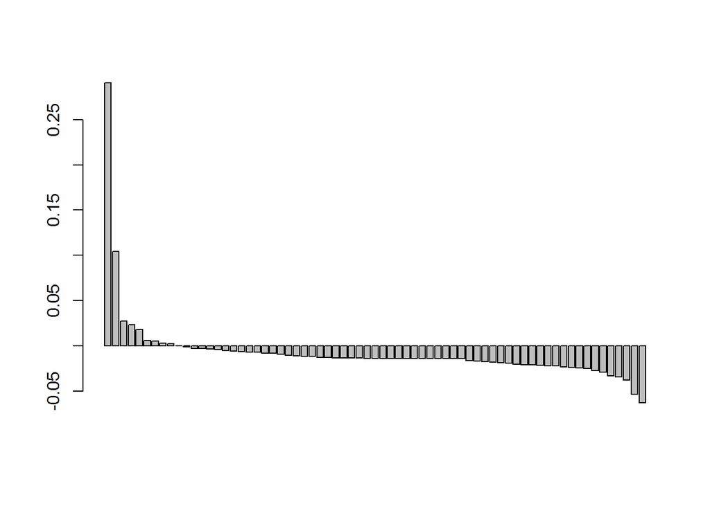

```r
barplot(attributes(mite.invdist.MEM)$values)
```

```r
# Store all MEM vectors in new object
mite.invdist.MEM.vec <- as.matrix(mite.invdist.MEM)

# Test of Moran's I of each eigenvector - 特征向量
mite.MEM.Moran <-
  moran.randtest(mite.invdist.MEM.vec,
                 mite.invdist.lw,
                 999)

# MEM with significant spatial correlation
which(mite.MEM.Moran$pvalue <=  0.05)
```

```
## [1] 1 2 3 4 5
```

```r
length(which(mite.MEM.Moran$pvalue <=  0.05))
```

```
## [1] 5
```

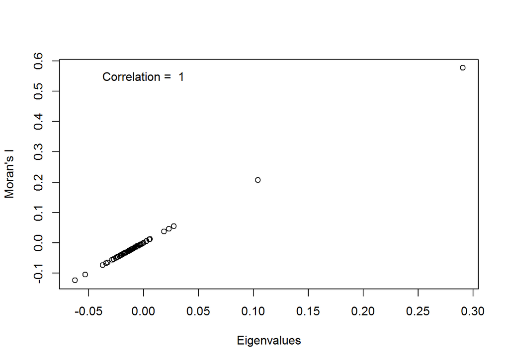

```r
# MEM with 正空间相关
MEM.Moran.pos <-
  which(mite.MEM.Moran$obs > -1/(nrow(mite.invdist.MEM.vec)-1))
mite.invdist.MEM.pos <- mite.invdist.MEM.vec[ ,MEM.Moran.pos]
# MEM with positive *and significant* spatial correlation - 两种筛选标准
mite.invdist.MEM.pos.sig <-
  mite.invdist.MEM.pos[ ,which(mite.MEM.Moran$pvalue <=  0.05)]
# 绘制类型 - I 的数据信息
plot(attributes(mite.invdist.MEM)$values,
     mite.MEM.Moran$obs,
     ylab = "Moran's I",
     xlab = "Eigenvalues"
     )
text(0,
     0.55,
     paste("Correlation = ",
           cor(mite.MEM.Moran$obs, attributes(mite.invdist.MEM)$values)
           )
     )
```

### 7.4.4 如何选择应用正空间相关的 MEM 或者负空间相关的 MEM

> 由上面的空间建模案例生成的 PCNM 变量和 MEM 变量中, 有些是模拟正空间相关, 有些是模拟负空间相关. 于是问题也随之产生: 应该将所有显著的空间变量都作为解释变量进行下一步的典范排序或者多元回归分析? 还是只选正空间相关变量?

> 这个问题没有明确的答案. 从生态学的角度讲, 自然界连续变化的过程往往呈现正空间相关的现象, 因此一般情况下正空间相关更受关注. 另一方面, 经验论, 显著的负空间相关往往与局部的偶然数据结构有关, 在变差分解过程中它们属于纯的空间组分, 即与生物的相互作用有关. 如果对负空间相关感兴趣, 所有的特征向量都应该考虑进入下一步的分析.

### 7.4.5 非对称的特征向量图(Asymmetric Eigenvector Maps, AEM): 方向性很重要时(When Directionality Matters)

#### 7.4.5.1 简介

PCNM 和 MEN 是模拟物理过程产生的无方向性的响应空间结构(如群落). **换言之, 任何位置的点对周围的影响不具有方向性.** 分析过程中遗漏的方向性结构信息.

然而, 在某些情况下, 必须考虑方向性. 比如河流的上下游, 特殊区域的物理过程具有地理不对称性, 即一个点对另一个点的影响一般是从上游到下游的方向, 但鱼类从下游到上游的洄游方向则相反.

方向性过程可能会让数据产生趋势, 所以数据的趋势不一定在非对称特征向量图(Asymmetric Eigenvector Maps modelling method, AEM)分析之前提取, 数据的趋势分析应属于 AEM 分析的一部分.

AEM 分析是专为具有方向性的因果关系的物理过程驱动群落的分析而设计的. 这种空间结构与简单的生态梯度不同, 生态梯度是指生态因子具有空间结构, 但同时不排除群落本身也可以在任何方向有相互作用. **因此, 对于生态梯度, PCNM和MEM可能会更适用.**

#### 7.4.5.2 非对称的特征向量图(Asymmetric Eigenvector Maps, AEM)分析方法的原理与应用

```r
# 编码 - 河流 arborescence 数据集; See Legendre and Legendre (2012, p. 889).
node1 <- c(1, 0, 0, 0, 0, 0, 0, 0)
n2lk6 <- c(0, 1, 0, 0, 0, 0, 0, 0)
n3lk3 <- c(1, 0, 1, 0, 0, 0, 0, 0)
n4lk2 <- c(1, 0, 0, 1, 0, 0, 0, 0)
node5 <- c(0, 1, 0, 0, 1, 0, 0, 0)
n6lk1 <- c(1, 0, 0, 1, 0, 1, 0, 0)
ln7k4 <- c(0, 1, 0, 0, 1, 0, 1, 0)
n8lk5 <- c(0, 1, 0, 0, 1, 0, 0, 1)
arbor <- rbind(node1, n2lk6, n3lk3, n4lk2, node5,
               n6lk1, ln7k4, n8lk5)

# 构建非对称的特征向量图(Asymmetric Eigenvector Maps, AEM)
(arbor.aem <- aem(binary.mat = arbor))
```

```
## $values
## [1] 0.92733656 0.23480505 0.14285714 0.10866056 0.06605143 0.03896014
## [7] 0.03490055
##
## $vectors
##            [,1]       [,2]          [,3]        [,4]        [,5]
## [1,] -0.2501511  0.2716811  7.157798e-16 -0.09935854  0.42148430
## [2,]  0.1713696  0.1078259  5.299508e-15 -0.81552275 -0.19996826
## [3,] -0.2957047  0.6937852 -1.869513e-15  0.31571448 -0.36246835
## [4,] -0.3768218 -0.2337882  1.474507e-16 -0.02572178  0.60456990
## [5,]  0.3557302 -0.0397038  3.547350e-16 -0.10142883 -0.07819983
## [6,] -0.4454427 -0.5970190 -5.549353e-16  0.08173167 -0.51991844
## [7,]  0.4205103 -0.1013906  7.071068e-01  0.32229288  0.06725034
## [8,]  0.4205103 -0.1013906 -7.071068e-01  0.32229288  0.06725034
##             [,6]        [,7]
## [1,]  0.69752464 -0.25407096
## [2,] -0.02459123  0.35824107
## [3,] -0.26156344  0.08213687
## [4,] -0.53997872  0.14354453
## [5,] -0.29547924 -0.80197794
## [6,]  0.20248559 -0.04640553
## [7,]  0.11080120  0.25926598
## [8,]  0.11080120  0.25926598
```

```r
arbor.aem.vec <- arbor.aem$vectors

# AEM特征函数也可以通过奇异值分解(svd())直接获得, 这是函数aem（）所做的:
# 质心化 - 中心化处理矩阵(数据框)数据 - Centring
# scale() 对矩阵相似对象进行缩放或者居中
# https://www.rdocumentation.org/packages/base/versions/3.6.0/topics/scale
# 默认 center = T, 减去列平均值然后 centered
# center = F, 减去列平均值
arbor.c <- scale(arbor,
                 center = TRUE,
                 scale = FALSE)
# https://www.rdocumentation.org/packages/base/versions/3.6.0/topics/svd
# svd() - 矩阵的奇异值分解 - Singular Value Decomposition Of A Matrix
arbor.svd <- svd(arbor.c)
# 奇异值 of the construction above
arbor.svd$d[1:7]
```

```
## [1] 2.5478139 1.2820434 1.0000000 0.8721376 0.6799706 0.5222269 0.4942710
```

```r
# AEM 本征函数 eigenfunctions of the construction above
arbor.svd$u[ ,1:7]
```

```
##            [,1]       [,2]          [,3]        [,4]        [,5]
## [1,] -0.2501511  0.2716811  7.157798e-16 -0.09935854  0.42148430
## [2,]  0.1713696  0.1078259  5.299508e-15 -0.81552275 -0.19996826
## [3,] -0.2957047  0.6937852 -1.869513e-15  0.31571448 -0.36246835
## [4,] -0.3768218 -0.2337882  1.474507e-16 -0.02572178  0.60456990
## [5,]  0.3557302 -0.0397038  3.547350e-16 -0.10142883 -0.07819983
## [6,] -0.4454427 -0.5970190 -5.549353e-16  0.08173167 -0.51991844
## [7,]  0.4205103 -0.1013906  7.071068e-01  0.32229288  0.06725034
## [8,]  0.4205103 -0.1013906 -7.071068e-01  0.32229288  0.06725034
##             [,6]        [,7]
## [1,]  0.69752464 -0.25407096
## [2,] -0.02459123  0.35824107
## [3,] -0.26156344  0.08213687
## [4,] -0.53997872  0.14354453
## [5,] -0.29547924 -0.80197794
## [6,]  0.20248559 -0.04640553
## [7,]  0.11080120  0.25926598
## [8,]  0.11080120  0.25926598
```

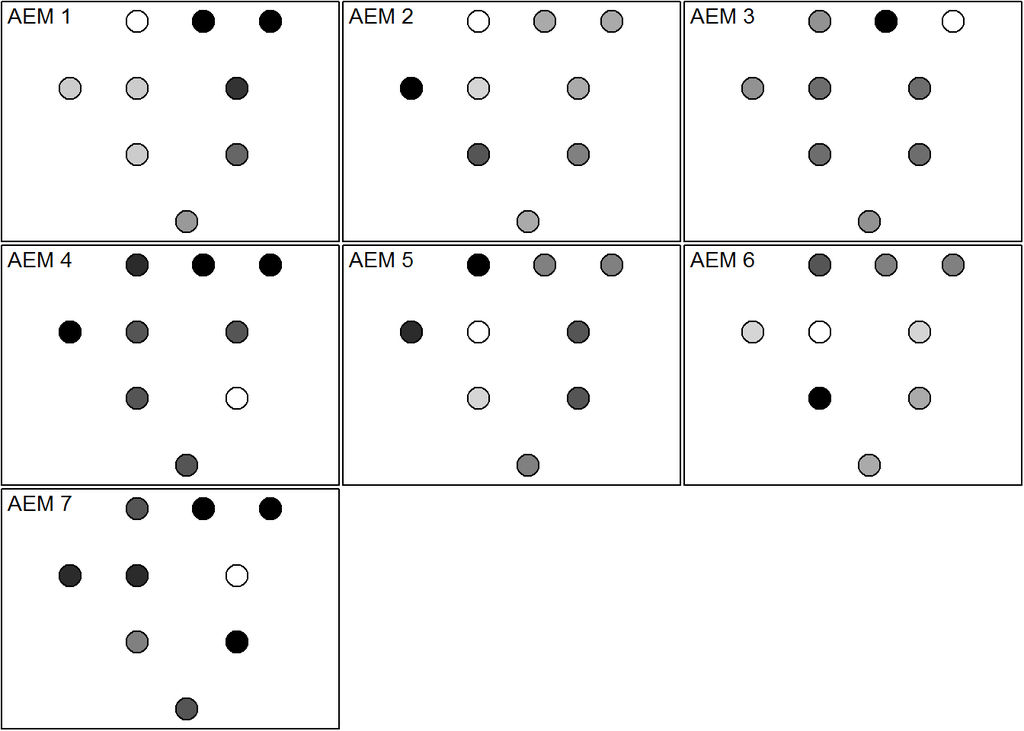

```r
# ---->>>在本书中绘制===========
# 非对称的特征向量图(Asymmetric Eigenvector Maps, AEM)
# 图中位点的坐标
xx <- c(2.75, 2, 3.5, 1, 2, 3.5, 2, 3, 4)
yy <- c(1,2,2,3,3,3,4,4,4)
data.xy <- data.frame(xx,yy)
rownames(data.xy) <-
  c("N0", "N1", "N2", "N3", "N4", "N5", "N6", "N7", "N8")
arbor.points <-
  rbind(rep(0,7), arbor.svd$u[ ,1:7]) # With node 0 added
# 改变显著值 of AEM 5
arbor.points[ ,5] <- -arbor.points[ ,5]
par(mfrow = c(3,3))
for(i in 1:7) {
  sr.value(data.xy,
         arbor.points[ ,i],
         method = "greylevel",
         csize = 1,
         clegend = 0,
         grid = FALSE,
         include.origin = FALSE,
         addaxes = FALSE,
         sub = paste("AEM",i),
         csub = 2)
  }
# <<<--- 本书中的相关章节结束 ===========
```

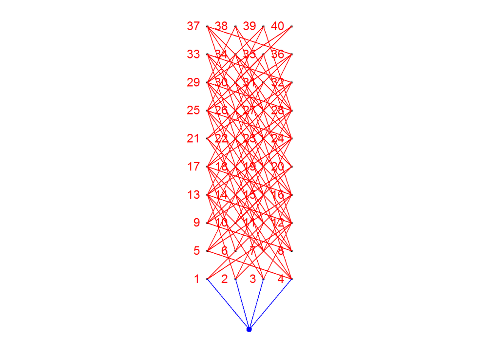

```r
# 采样设计编码：10个跨河断面，每个断面4个陷阱。 边缘加权与反平方距离成比例。
# X-Y coordinates
# # 生成网格点坐标 - Generate grid point coordinates
# https://www.rdocumentation.org/packages/base/versions/3.6.0/topics/expand.grid
# expand.grid - 从因子变量的所有组合创建数据框
xy <- cbind(1:40, expand.grid(1:4, 1:10))
# Object of class nb (spdep) containing links of chess type "queen"
# https://www.rdocumentation.org/packages/spdep/versions/1.1-2/topics/cell2nb
# cell2nb - 生成网格单元的邻近列表
nb <- cell2nb(4, 10, "queen")
# Site-by-edges matrix  (produces a fictitious object "0") with automatic plot of the site-by-edges matrix
# aem.build.binary - 构建Site-by-edges二进制矩阵
# https://www.rdocumentation.org/packages/adespatial/versions/0.3-4/topics/aem.build.binary
edge.mat <- aem.build.binary(nb, xy)
```

```r
D1.mat <- as.matrix(dist(xy)) # 欧式距离 Euclidean distances
# Extract the edges, remove the ones directly linked to site 0
edges.b <- edge.mat$edges[-1:-4,]
# 创建向量
length.edge <- vector(length = nrow(edges.b))
for(i in 1:nrow(edges.b)) {
  length.edge[i] <- D1.mat[edges.b[i,1], edges.b[i,2]]
  }
# Weighting of edges based on inverse squared distance
# 基于反平方距离的边的加权
weight.vec <- 1-(length.edge/max(length.edge))^2
# 构造 AEM 特征函数 from edge.mat, of class build.binary
# 非对称的特征向量图(Asymmetric Eigenvector Maps, AEM)
example.AEM <-
  aem(aem.build.binary = edge.mat,
      weight = weight.vec,
      rm.link0 = TRUE)

example.AEM$values
```

```
##  [1] 5.061505e-01 4.043334e-01 1.423704e-01 9.763484e-02 6.136483e-02
##  [6] 4.571704e-02 2.803352e-02 2.383343e-02 1.625822e-02 1.343454e-02
## [11] 1.086950e-02 9.499819e-03 7.255933e-03 6.373591e-03 5.845349e-03
## [16] 4.334630e-03 3.518474e-03 3.326126e-03 3.105122e-03 2.666058e-03
## [21] 2.298037e-03 1.931245e-03 1.534129e-03 1.450208e-03 1.047919e-03
## [26] 9.744631e-04 6.139366e-04 4.739176e-04 3.985959e-04 2.509450e-04
## [31] 2.140600e-04 7.121004e-05 9.982058e-32 4.476827e-33 4.476827e-33
## [36] 4.476827e-33 4.476827e-33 4.476827e-33 4.476827e-33
```

```r
ex.AEM.vec <- example.AEM$vectors
# 创建 5 个虚拟物种
# 两个随机分布的物种
# trunc - 模拟截断分布
sp12 <- matrix(trunc(rnorm(80,5,2),0),40)
# 一种物种仅限于溪流的上半部分
sp3 <- c(trunc(rnorm(20,8,2.5),0), rep(0,20))
# 一个物种仅限于横断面的左半部分
sp4 <- t(matrix(c(trunc(rnorm(20,8,3),0), rep(0,20)),10))
sp4 <- as.vector(sp4)
# 一种物种仅限于4个左上部位
sp5 <- c(4,7,0,0,3,8, rep(0,34))
# 创建物种矩阵
sp <- cbind(sp12, sp3, sp4, sp5)
colnames(sp) <- c("sp1", "sp2", "sp3", "sp4", "sp5")

# Global AEM analysis with 20 first AEM variables (for computation of R2a)
# 具有20个第一个AEM变量的全局AEM分析（用于计算R2a）
# https://www.rdocumentation.org/packages/vegan/versions/2.4-2/topics/cca
AEM.20 <- rda(sp ~ .,
              as.data.frame(ex.AEM.vec[ ,1:20]))
# https://www.rdocumentation.org/packages/vegan/versions/2.4-2/topics/RsquareAdj
(R2a.AEM <- RsquareAdj(AEM.20)$adj.r.squared)
```

```
## [1] -0.03739207
```

```r
# 非对称的特征向量图(Asymmetric Eigenvector Maps, AEM)变量的前向选择
# https://www.rdocumentation.org/packages/adespatial/versions/0.3-4/topics/forward.sel
# 通过简化模型下的残差置换进行前向选择
AEM.fwd <- forward.sel(sp,
                       ex.AEM.vec)
```

```
## Testing variable 1
## Testing variable 2
## Testing variable 3
## Testing variable 4
## Procedure stopped (alpha criteria): pvalue for variable 4 is 0.051000 (> 0.050000)
```

```r
# AEM.fwd <- forward.sel(sp,
#                        ex.AEM.vec,
#                        adjR2thresh = R2a.AEM)
# R2a.AEM - 为负值, 运行报错; 官网给的该参数可以为负值...相互矛盾, 问题在何处?
(AEM.sign <- sort(AEM.fwd[ ,2]))
```

```
## [1]  1  4 28
```

```r
# 保存显著性的结果
AEM.sign.vec <- ex.AEM.vec[ ,c(AEM.sign)]
# RDA with signif. AEM - 冗余分析
# https://www.rdocumentation.org/packages/vegan/versions/2.4-2/topics/cca
(sp.AEMsign.rda <- rda(sp ~ .,
                       data = as.data.frame(AEM.sign.vec)))
```

```
## Call: rda(formula = sp ~ V1 + V2 + V3, data =
## as.data.frame(AEM.sign.vec))
##
##               Inertia Proportion Rank
## Total         51.1494     1.0000
## Constrained   16.6859     0.3262    3
## Unconstrained 34.4635     0.6738    5
## Inertia is variance
##
## Eigenvalues for constrained axes:
##   RDA1   RDA2   RDA3
## 11.196  5.451  0.038
##
## Eigenvalues for unconstrained axes:
##    PC1    PC2    PC3    PC4    PC5
## 15.619 10.303  4.241  2.523  1.776
```

```r
anova(sp.AEMsign.rda)
```

```
## Permutation test for rda under reduced model
## Permutation: free
## Number of permutations: 999
##
## Model: rda(formula = sp ~ V1 + V2 + V3, data = as.data.frame(AEM.sign.vec))
##          Df Variance      F Pr(>F)
## Model     3   16.686 5.8099  0.001 ***
## Residual 36   34.463
## ---
## Signif. codes:  0 '***' 0.001 '**' 0.01 '*' 0.05 '.' 0.1 ' ' 1
```

```r
(AEM.rda.axes.test <- anova(sp.AEMsign.rda,
                            by = "axis"))
```

```
## Permutation test for rda under reduced model
## Forward tests for axes
## Permutation: free
## Number of permutations: 999
##
## Model: rda(formula = sp ~ V1 + V2 + V3, data = as.data.frame(AEM.sign.vec))
##          Df Variance       F Pr(>F)
## RDA1      1   11.196 11.6954  0.001 ***
## RDA2      1    5.451  5.6942  0.005 **
## RDA3      1    0.038  0.0402  0.994
## Residual 36   34.463
## ---
## Signif. codes:  0 '***' 0.001 '**' 0.01 '*' 0.05 '.' 0.1 ' ' 1
```

```r
# 显著性轴的数量
(nb.ax.AEM <- length(which(AEM.rda.axes.test[ ,4] <=  0.05)))
```

```
## [1] 2
```

```r
# 调整的 R方
RsquareAdj(sp.AEMsign.rda)
```

```
## $r.squared
## [1] 0.3262185
##
## $adj.r.squared
## [1] 0.2700701
```

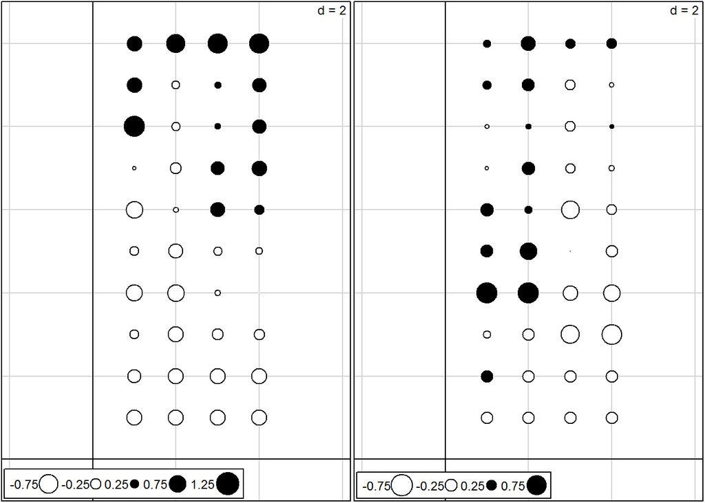

```r
# 绘制显著性的典范轴 - canonical axis
# 质心化 - 中心化处理矩阵(数据框)数据 - Centring
# scale() 对矩阵相似对象进行缩放或者居中
# https://www.rdocumentation.org/packages/base/versions/3.6.0/topics/scale
# 默认 center = T, 减去列平均值然后 centered
# center = F, 减去列平均值
AEM.rda.axes <-
  scores(sp.AEMsign.rda,
         choices = c(1,2),
         display = "lc",
         scaling = 1)

par(mfrow = c(1,nb.ax.AEM))
for(i in 1:nb.ax.AEM) sr.value(xy[ ,c(2,3)], AEM.rda.axes[ ,i])
```

## 7.5 另一种空间结构的观察方法: 多尺度排序(Multiscale Ordination, MSO)

### 7.5.1 多尺度排序(Multiscale Ordination, MSO)方法的基本原理

Wagner 引入统计学方法中的设计诊断工具, 将排序结果划分给不同的距离等级, 然后区分诱导性空间依赖于空间自相关, 并使用变异函数检验重要的统计假设, 例如残差的独立性和稳定性.

多尺度排序(Multiscale Ordination, MSO)的计算步骤:

变异函数矩阵是包含距离等级和方差-协方差矩阵的三维数组. 每个矩阵的对角线量化所对应距离等级对于数据总方差的贡献. MSO 通过计算约束排序拟合值的变异函数矩阵, 从而是空间结构分解. 将变异函数矩阵乘以典型特征向量将获得每个特征值的空间分解. 残差的空间分解也可利用相同的方式进行.

### 7.5.2 多尺度排序(Multiscale Ordination, MSO)方法在甲螨数据集探索性分析中的应用

```r
## 多尺度排序(Multiscale Ordination, MSO) vs 环境冗余分析 RDA -- 螨虫数据集
# https://www.rdocumentation.org/packages/vegan/versions/2.4-2/topics/cca
# https://www.rdocumentation.org/packages/vegan/versions/2.4-0/topics/mso
# 执行和显示空间分割CCA或RDA结果
# Functions For Performing And Displaying A Spatial Partitioning Of Cca Or Rda Results
mite.undet.env.rda <- rda(mite.h~., mite.env2)
(mite.env.rda.mso <-
  mso(mite.undet.env.rda,
      mite.xy,
      grain = dmin,
      perm = 999))
```

```
## Call: mso(object.cca = mite.undet.env.rda, object.xy = mite.xy,
## grain = dmin, permutations = 999)
##
##               Inertia Proportion Rank
## Total          0.3943     1.0000
## Constrained    0.2076     0.5265   11
## Unconstrained  0.1867     0.4735   35
## Inertia is variance
##
## Eigenvalues for constrained axes:
##    RDA1    RDA2    RDA3    RDA4    RDA5    RDA6    RDA7    RDA8    RDA9
## 0.13731 0.02466 0.01382 0.01118 0.00830 0.00548 0.00211 0.00189 0.00127
##   RDA10   RDA11
## 0.00098 0.00057
##
## Eigenvalues for unconstrained axes:
##     PC1     PC2     PC3     PC4     PC5     PC6     PC7     PC8
## 0.04274 0.02385 0.01720 0.01369 0.01157 0.00968 0.00769 0.00727
## (Showing 8 of 35 unconstrained eigenvalues)
##
## mso variogram:
##
##                 H   Dist   n      All      Sum       CA      CCA        se
## 0               0 0.3555  63 0.002959 0.003606 0.002411 0.001196 2.081e-04
## 1.011187 1.011187 1.0659 393 0.003584 0.004098 0.002668 0.001430 9.725e-05
## 2.022374 2.022374 2.0199 546 0.004335 0.004526 0.002638 0.001888 9.536e-05
## 3.033561 3.033561 2.9938 406 0.005620 0.005456 0.002693 0.002763 1.241e-04
## 4.044748 4.044748 3.9964 329 0.006973 0.006397 0.002674 0.003723 1.477e-04
## 5.055935 5.055935 5.0532 245 0.007916 0.007426 0.002730 0.004695 1.729e-04
## 10.11187 10.11187 6.8305 433 0.007673 0.007740 0.002890 0.004850 1.190e-04
##          CA.signif
## 0            0.031
## 1.011187     0.522
## 2.022374     0.230
## 3.033561     0.864
## 4.044748     0.626
## 5.055935     0.717
## 10.11187     0.163
##
## Permutation: free
## Number of permutations: 999
```

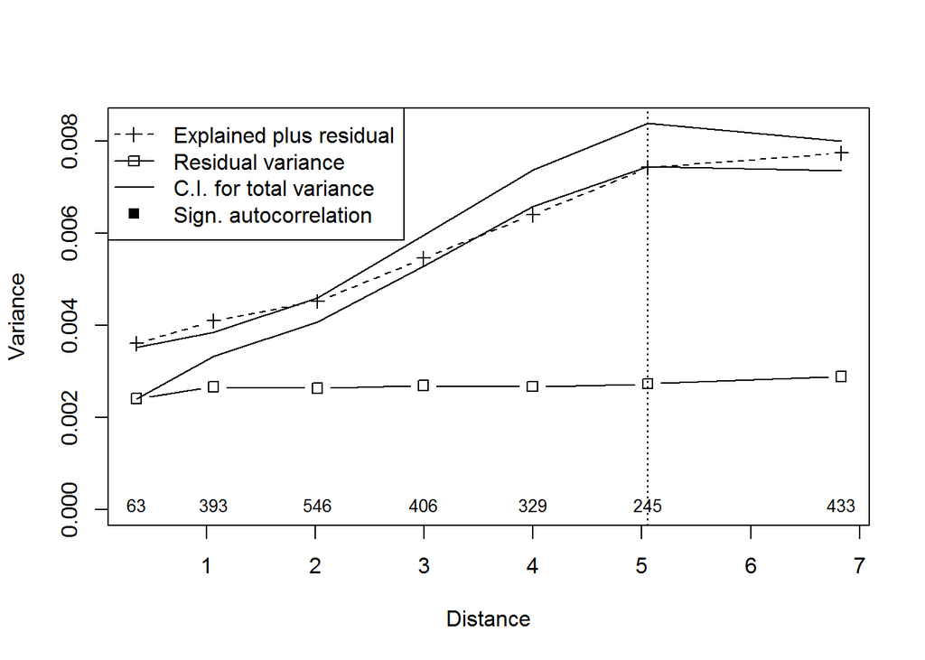

```
## Error variance of regression model underestimated by NaN percent
```

```r
msoplot(mite.env.rda.mso,
        alpha = 0.05/7)
```

```r
# MSO of the undetrended mite data vs environment RDA, controlling  for MEM
mite.undet.env.MEM <-
  rda(mite.h,
      mite.env2,
      as.data.frame(MEM.select))
(mite.env.MEM.mso <-
  mso(mite.undet.env.MEM,
      mite.xy,
      grain = dmin,
      perm = 999))
```

```
## Call: mso(object.cca = mite.undet.env.MEM, object.xy = mite.xy,
## grain = dmin, permutations = 999)
##
##               Inertia Proportion Rank
## Total         0.39428    1.00000
## Conditional   0.19381    0.49155    6
## Constrained   0.05901    0.14967   11
## Unconstrained 0.14146    0.35878   35
## Inertia is variance
##
## Eigenvalues for constrained axes:
##     RDA1     RDA2     RDA3     RDA4     RDA5     RDA6     RDA7     RDA8
## 0.022782 0.014609 0.007637 0.003424 0.003222 0.002347 0.001762 0.001181
##     RDA9    RDA10    RDA11
## 0.000986 0.000718 0.000343
##
## Eigenvalues for unconstrained axes:
##     PC1     PC2     PC3     PC4     PC5     PC6     PC7     PC8
## 0.03282 0.01310 0.01218 0.01047 0.00947 0.00797 0.00719 0.00593
## (Showing 8 of 35 unconstrained eigenvalues)
##
## mso variogram:
##
##                 H   Dist   n      All      Sum       CA       CCA
## 0               0 0.3555  63 0.002978 0.003102 0.002122 0.0009795
## 1.011187 1.011187 1.0659 393 0.003050 0.003065 0.002183 0.0008818
## 2.022374 2.022374 2.0199 546 0.002929 0.002906 0.002052 0.0008544
## 3.033561 3.033561 2.9938 406 0.002829 0.002801 0.001981 0.0008204
## 4.044748 4.044748 3.9964 329 0.002943 0.002875 0.002016 0.0008588
## 5.055935 5.055935 5.0532 245 0.002825 0.002829 0.001981 0.0008479
## 10.11187 10.11187 6.8305 433 0.002822 0.002895 0.002047 0.0008482
##               pCCA        se CA.signif
## 0        5.911e-05 2.057e-04     0.518
## 1.011187 4.765e-04 7.893e-05     0.005
## 2.022374 1.453e-03 6.073e-05     0.967
## 3.033561 2.935e-03 6.697e-05     0.196
## 4.044748 4.020e-03 7.861e-05     0.512
## 5.055935 4.931e-03 8.368e-05     0.203
## 10.11187 4.796e-03 6.841e-05     0.966
##
## Permutation: free
## Number of permutations: 999
```

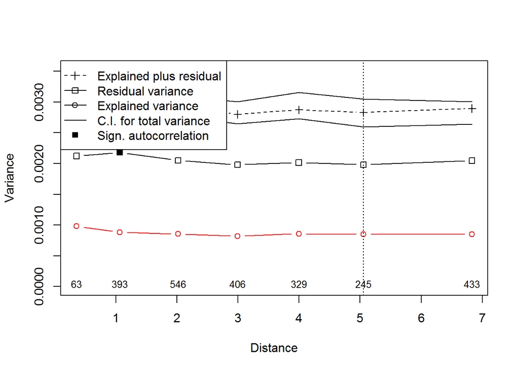

```
## Error variance of regression model underestimated by -1.3 percent
```

```r
msoplot(mite.env.MEM.mso,
        alpha = 0.05/7)
```

### 7.5.3 多尺度排序(Multiscale Ordination, MSO)方法在甲螨数据集和环境数据集中的应用

```r
# 对'去势'螨虫数据和环境数据进行多尺度排序分析(Multiscale Ordination, MSO)
# resid() - 提取模型残差
# Detrend 螨虫数据 on Y coordinate - 去势
mite.h.det2 <- resid(lm(as.matrix(mite.h) ~ mite.xy[ ,2]))
# Detrend 环境数据 on Y coordinate - 去势
env2.det <- as.data.frame(
                    resid(lm(as.matrix(mite.env2) ~ mite.xy[ ,2])))
# RDA & MSO
mitedet.envdet.rda <- rda(mite.h.det2 ~., env2.det)
(miteenvdet.rda.mso <-
  mso(mitedet.envdet.rda,
      mite.xy,
      grain = dmin,
      perm = 999))
```

```
## Call: mso(object.cca = mitedet.envdet.rda, object.xy = mite.xy,
## grain = dmin, permutations = 999)
##
##               Inertia Proportion Rank
## Total          0.2890     1.0000
## Constrained    0.1158     0.4007   11
## Unconstrained  0.1732     0.5993   35
## Inertia is variance
##
## Eigenvalues for constrained axes:
##    RDA1    RDA2    RDA3    RDA4    RDA5    RDA6    RDA7    RDA8    RDA9
## 0.05659 0.01958 0.01502 0.00841 0.00590 0.00341 0.00273 0.00172 0.00136
##   RDA10   RDA11
## 0.00069 0.00041
##
## Eigenvalues for unconstrained axes:
##     PC1     PC2     PC3     PC4     PC5     PC6     PC7     PC8
## 0.04274 0.01997 0.01520 0.01164 0.01036 0.00897 0.00767 0.00719
## (Showing 8 of 35 unconstrained eigenvalues)
##
## mso variogram:
##
##                 H   Dist   n      All      Sum       CA      CCA        se
## 0               0 0.3555  63 0.002960 0.003485 0.002305 0.001180 2.089e-04
## 1.011187 1.011187 1.0659 393 0.003539 0.003837 0.002505 0.001332 9.696e-05
## 2.022374 2.022374 2.0199 546 0.004120 0.004161 0.002506 0.001656 8.900e-05
## 3.033561 3.033561 2.9938 406 0.004827 0.004525 0.002527 0.001998 1.054e-04
## 4.044748 4.044748 3.9964 329 0.004800 0.004457 0.002463 0.001994 1.072e-04
## 5.055935 5.055935 5.0532 245 0.004277 0.004188 0.002529 0.001659 1.155e-04
## 10.11187 10.11187 6.8305 433 0.003933 0.004128 0.002562 0.001566 9.850e-05
##          CA.signif
## 0            0.132
## 1.011187     0.934
## 2.022374     0.935
## 3.033561     0.821
## 4.044748     0.455
## 5.055935     0.779
## 10.11187     0.702
##
## Permutation: free
## Number of permutations: 999
```

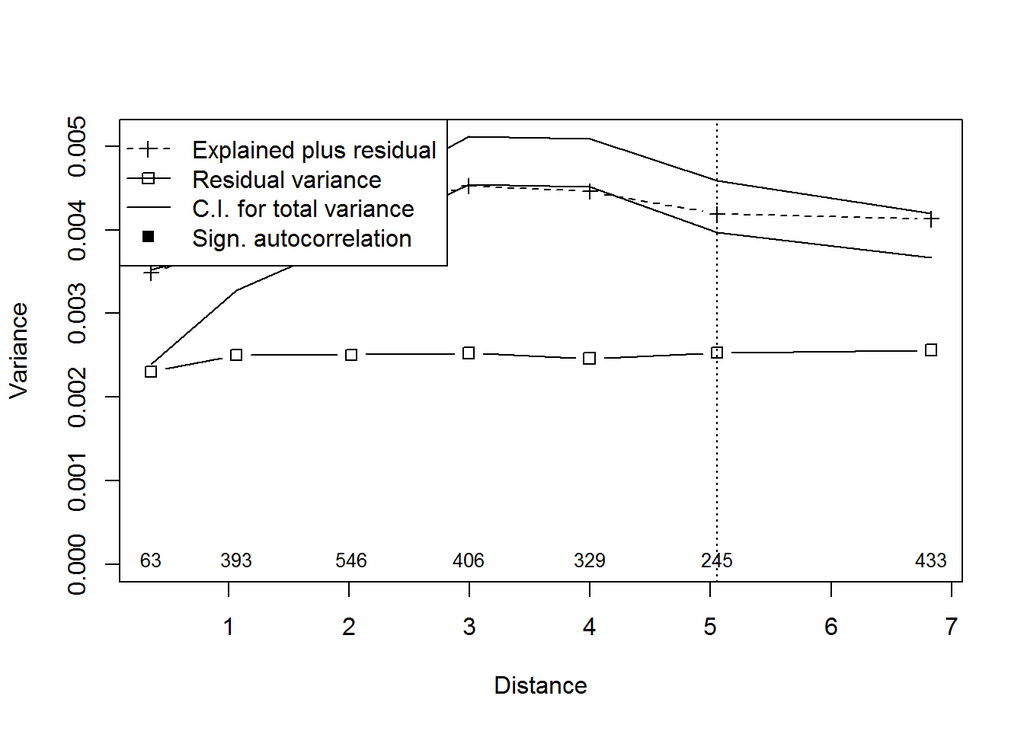

```
## Error variance of regression model underestimated by NaN percent
```

```r
msoplot(miteenvdet.rda.mso, alpha = 0.05/7)
```

```r
# MSO of the detrended mite data vs detrended environment RDA, controlling for MEM
mite.det.env.MEM <-
  rda(mite.h.det2,
      env2.det,
      as.data.frame(MEM.select))
(mite.env.MEM.mso <-
  mso(mite.det.env.MEM,
      mite.xy,
      grain = dmin,
      perm = 999))
```

```
## Call: mso(object.cca = mite.det.env.MEM, object.xy = mite.xy,
## grain = dmin, permutations = 999)
##
##               Inertia Proportion Rank
## Total         0.28905    1.00000
## Conditional   0.09031    0.31243    6
## Constrained   0.05994    0.20736   11
## Unconstrained 0.13880    0.48021   35
## Inertia is variance
##
## Eigenvalues for constrained axes:
##     RDA1     RDA2     RDA3     RDA4     RDA5     RDA6     RDA7     RDA8
## 0.023063 0.014394 0.007857 0.003647 0.003190 0.002430 0.002341 0.001133
##     RDA9    RDA10    RDA11
## 0.000936 0.000590 0.000355
##
## Eigenvalues for unconstrained axes:
##     PC1     PC2     PC3     PC4     PC5     PC6     PC7     PC8
## 0.03256 0.01307 0.01157 0.01043 0.00929 0.00736 0.00672 0.00593
## (Showing 8 of 35 unconstrained eigenvalues)
##
## mso variogram:
##
##                 H   Dist   n      All      Sum       CA       CCA
## 0               0 0.3555  63 0.002977 0.003093 0.002109 0.0009836
## 1.011187 1.011187 1.0659 393 0.003045 0.003039 0.002139 0.0008994
## 2.022374 2.022374 2.0199 546 0.002900 0.002890 0.002014 0.0008757
## 3.033561 3.033561 2.9938 406 0.002801 0.002765 0.001936 0.0008288
## 4.044748 4.044748 3.9964 329 0.002932 0.002857 0.001987 0.0008701
## 5.055935 5.055935 5.0532 245 0.002803 0.002807 0.001934 0.0008732
## 10.11187 10.11187 6.8305 433 0.002772 0.002861 0.002012 0.0008486
##               pCCA        se CA.signif
## 0        5.427e-05 2.047e-04     0.409
## 1.011187 4.371e-04 7.825e-05     0.015
## 2.022374 1.251e-03 6.020e-05     0.960
## 3.033561 2.076e-03 6.511e-05     0.153
## 4.044748 1.827e-03 7.767e-05     0.629
## 5.055935 1.413e-03 8.256e-05     0.152
## 10.11187 1.183e-03 6.768e-05     0.998
##
## Permutation: free
## Number of permutations: 999
```

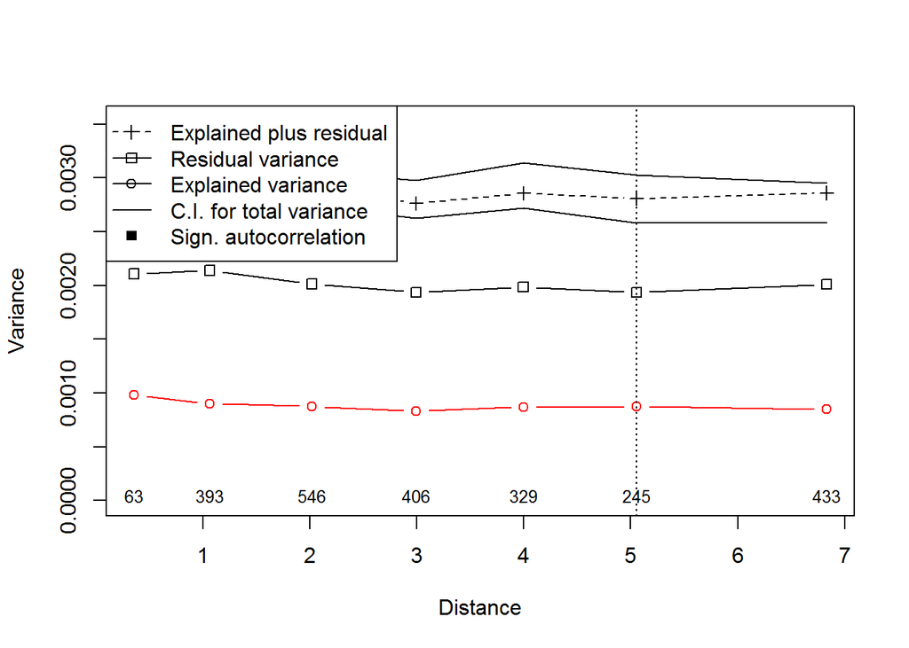

```
## Error variance of regression model underestimated by NaN percent
```

```r
msoplot(mite.env.MEM.mso, alpha = 0.05/7)
```

## 7.6 多元变量方差分析中的无重复时空交互检验(Space-Time Interaction Test in Multivariate ANOVA, Without Replicates)

### 7.6.2 使用 sti() 函数进行时空交互检验

```r
# 导入 adespatial 包中的内置数据集
data(trichoptera)
names(trichoptera) # 物种代码
```

```
##  [1] "Site"     "Date"     "CHEUMINU" "HYDRVALH" "CHEUPETI" "OXYEGRIS"
##  [7] "NEOTOKOP" "HYDSSPAR" "MICRWATA" "HYDRDELI" "CERADILU" "HYDRWYOM"
## [13] "NYCTMOES" "HYDSBETT" "MAYAAYAM" "OECEPERS" "HYDRNOVI" "CHEU.OXA"
## [19] "HYDRXONC" "POLYCONF" "OECEINCO" "CHEUHALI" "LEPISWAN" "HELIBORE"
## [25] "POLYCINE" "CHIMATER" "NEOPOBLI" "HYDRSPIN" "PYCNGUTT" "HYDRAMPO"
## [31] "NECTEXQU" "TRIAIGNI" "LYPEDIVE" "HYDRFISK" "HYDRQUIN" "ORTHCURT"
## [37] "PSYCFLAV" "RHYAFUSC" "ORTHAEGE" "MYSTSEPU" "GLOSNIGR" "DIPLMODE"
## [43] "HYDSVENT" "POLYFLAV" "CERATARS" "OXYEFORC" "STAC.SP." "DOLODIST"
## [49] "HYDSALHE" "OCHR.SP." "OXYEROBE" "CERACONC" "MOLAULME" "PTILOCEL"
## [55] "POLYALBI" "RHYAMARM" "RHYAMINO" "HYDSSLOS"
```

```r
tricho.hel <- decostand(trichoptera[ ,-c(1,2)], "hel") # 数据变换

# 时空交互分析 - sti analysis
# https://www.rdocumentation.org/packages/adespatial/versions/0.3-4/topics/stimodels
# stimodels() - 使用无重复 ANOVA 方法进行时空交互分析 - Space-Time Interaction
stimodels(tricho.hel,
          S = 22, # 空间点数
          Ti = 10, # 时间数量
          model = "5") # 线性时空模型
```

```
## =======================================================
##         Space-time ANOVA without replicates
##
##   Pierre Legendre, Miquel De Caceres, Daniel Borcard
## =======================================================
##
##  Number of space points (s) = 22
##  Number of time points (tt) = 10
##  Number of observations (n = s*tt) = 220
##  Number of response variables (p) = 56
##
##  Computing dbMEMs to code for space
##  Truncation level for space dbMEMs = 1
##  Computing dbMEMs to code for time
##  Truncation level for time dbMEMs = 1
##
##  Number of space coding functions = 10
##
##  Number of time coding functions = 4
##
##  MODEL V: HELMERT CONTRAST FOR TESTING MAIN FACTORS.
##           SPACE AND TIME dbMEMs FOR TESTING INTERACTION.
##    Number of space variables = 21
##    Number of time variables = 9
##    Number of interaction variables = 40
##    Number of residual degrees of freedom = 149
##
##  Interaction test:   R2 = 0.1835   F = 2.313   P( 999 perm) = 0.001
##  Space test:         R2 = 0.2522   F = 6.0569   P( 999 perm) = 0.001
##  Time test:          R2 = 0.2688   F = 15.0608   P( 999 perm) = 0.001
## -------------------------------------------------------
##       Time for this computation = 6.400000  sec
## =======================================================
```

```r
# https://www.rdocumentation.org/packages/adespatial/versions/0.3-4/topics/stimodels
# 使用 quicksti() 快速的进行时空交互分析(Space-Time Interaction Test)
quicksti(tricho.hel,
         S = 22, # 空间点数
         Ti = 10) # 时间数量
```

```
## =========================================================
##         Space-time ANOVA without replicates
##
##   Pierre Legendre, Miquel De Caceres, Daniel Borcard
## ---------------------------------------------------------
##
##  Number of space points (s) = 22
##  Number of time points (tt) = 10
##  Number of observations (n = s*tt) = 220
##  Number of response variables (p) = 56
##  Significance level for the interaction test (alpha) = 0.05
##
##  Computing dbMEMs to code for space
##  Truncation level for space dbMEMs = 1
##  Computing dbMEMs to code for time
##  Truncation level for time dbMEMs = 1
##
##  Number of space coding functions = 10
##  Number of time coding functions = 4
##
## ------------------------------------------
##  Testing space-time interaction (model 5)
## ------------------------------------------
##
##    Number of space variables = 21
##    Number of time variables = 9
##    Number of interaction variables = 40
##    Number of residual degrees of freedom = 149
##
##  Interaction test:  R2 = 0.1835   F = 2.313   P( 999 perm) = 0.001
##
## ----------------------------------------------------------------------
##  Testing for the existence of separate spatial structures (model 6a)
## ----------------------------------------------------------------------
##
##    Number of space variables = 100
##    Number of time variables = 9
##    Number of residual degrees of freedom = 110
##
##  Space test:  R2 = 0.4739   F = 2.0256   P( 999 perm) = 0.001
##
## -----------------------------------------------------
##  Testing for separate temporal structures (model 6b)
## -----------------------------------------------------
##
##    Number of space variables = 21
##    Number of time variables = 88
##    Number of residual degrees of freedom = 110
##
##  Time test:   R2 = 0.4981   F = 2.4936   P( 999 perm) = 0.001
##
## ---------------------------------------------------------
##       Time for this computation = 10.610000  sec
## =========================================================
```